# Week 2: Starting with R

### 1.3.3 Question 10

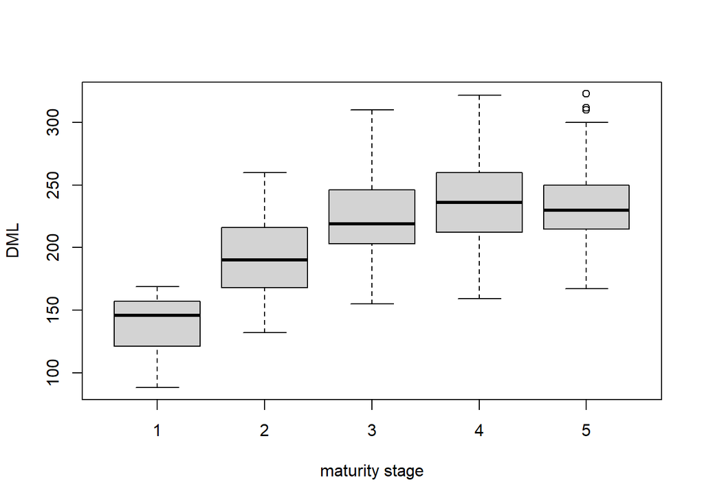

```r
install.packages('vioplot', repos = "http://cran.us.r-project.org")
library(vioplot)
boxplot(DML ~ maturity.stage, data = squid, xlab = "maturity stage", ylab = "DML")
```

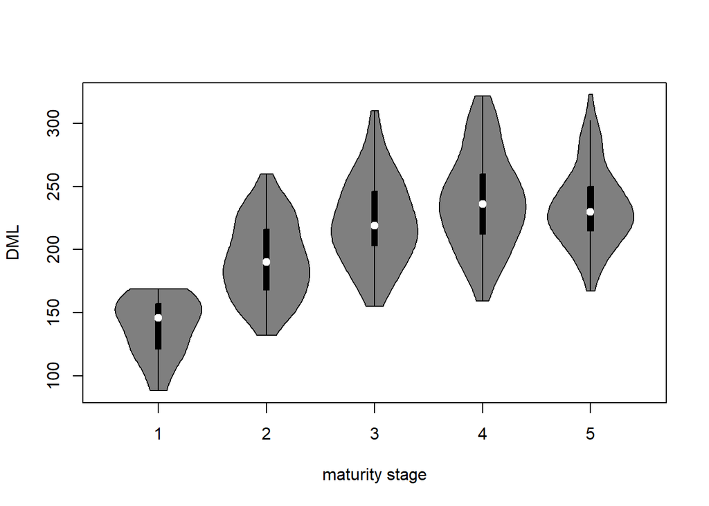

```r
vioplot(DML ~ maturity.stage, data = squid, xlab = "maturity stage", ylab = "DML")
```

### Question 11

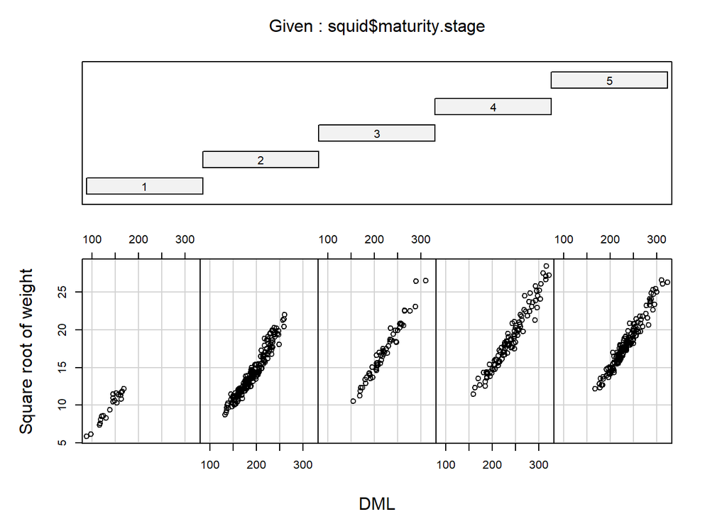

```r
coplot(squid$sqrtweight ~ squid$DML | squid$maturity.stage, columns=5, xlab = 'DML', ylab = 'Square root of weight')
```

### Question 12

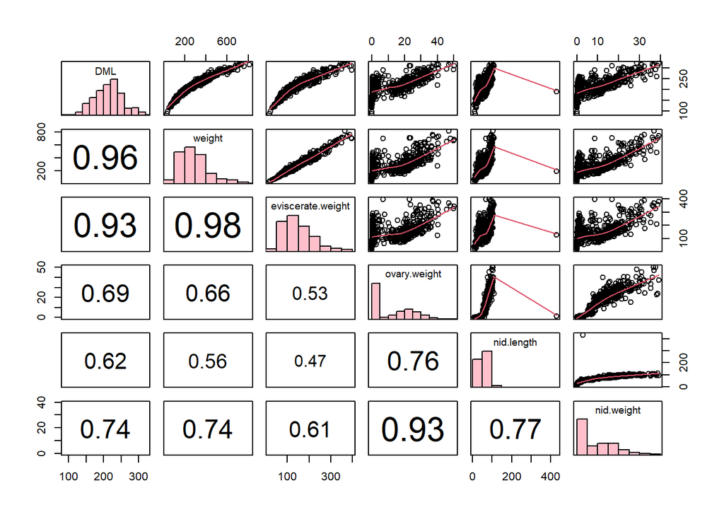

```r
# We first actually need to define panel.cor, or it won't knit the code. We used the following code from the Intro to R book:

panel.cor <- function(x, y, digits = 2, prefix = "", cex.cor, ...) {
  usr <- par("usr"); on.exit(par(usr))
  par(usr = c(0, 1, 0, 1))
  r <- abs(cor(x, y, use = "complete.obs"))  # Ensure missing values are handled
  txt <- format(c(r, 0.123456789), digits = digits)[1]
  txt <- paste0(prefix, txt)
  if (missing(cex.cor)) cex.cor <- 0.8 / strwidth(txt)
  text(0.5, 0.5, txt, cex = cex.cor * r)
}

panel.hist <- function(x, ...) {
  usr <- par("usr"); on.exit(par(usr))
  par(usr = c(usr[1:2], 0, 1.5) )
  h <- hist(x, plot = FALSE)
  breaks <- h$breaks; nB <- length(breaks)
  y <- h$counts; y <- y/max(y)
  rect(breaks[-nB], 0, breaks[-1], y, col = "pink", ...)
}

pairs(squid[, c("DML", "weight", "eviscerate.weight",
                "ovary.weight", "nid.length", 'nid.weight')],
                 lower.panel = panel.cor,
                 diag.panel = panel.hist,
                 upper.panel = panel.smooth)
```

### Question 13

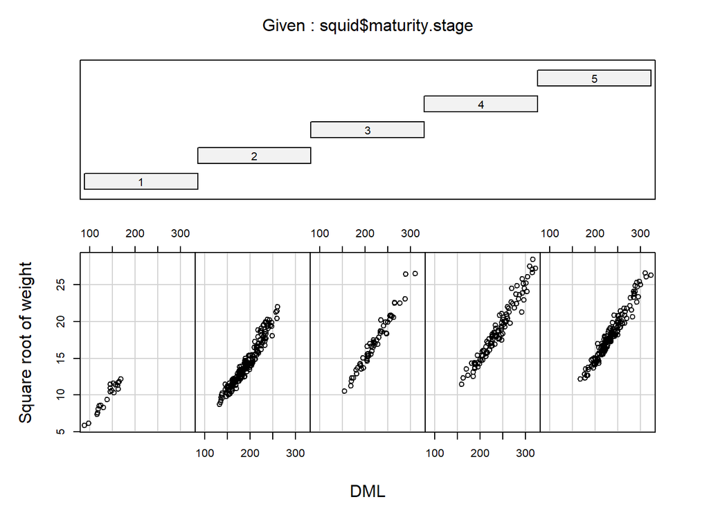

```r
coplot(squid$sqrtweight ~ squid$DML | squid$maturity.stage, columns=5, xlab = 'DML', ylab = 'Square root of weight')
```

# 2 Session Information

**R version 4.4.1 (2024-06-14 ucrt)**

**Platform:** x86_64-w64-mingw32/x64

**locale:** *LC_COLLATE=Dutch_Netherlands.utf8*, *LC_CTYPE=Dutch_Netherlands.utf8*, *LC_MONETARY=Dutch_Netherlands.utf8*, *LC_NUMERIC=C* and *LC_TIME=Dutch_Netherlands.utf8*

**attached base packages:** *stats*, *graphics*, *grDevices*, *utils*, *datasets*, *methods* and *base*

**other attached packages:** *vioplot(v.0.5.0)*, *zoo(v.1.8-12)*, *sm(v.2.2-6.0)* and *readr(v.2.1.5)*

**loaded via a namespace (and not attached):** *vctrs(v.0.6.5)*, *cli(v.3.6.3)*, *knitr(v.1.49)*, *rlang(v.1.1.4)*, *xfun(v.0.50)*, *jsonlite(v.1.8.9)*, *glue(v.1.7.0)*, *htmltools(v.0.5.8.1)*, *sass(v.0.4.9)*, *readxl(v.1.4.3)*, *hms(v.1.1.3)*, *rmarkdown(v.2.29)*, *pander(v.0.6.5)*, *grid(v.4.4.1)*, *cellranger(v.1.1.0)*, *evaluate(v.1.0.3)*, *jquerylib(v.0.1.4)*, *tibble(v.3.2.1)*, *tzdb(v.0.4.0)*, *fastmap(v.1.2.0)*, *yaml(v.2.3.10)*, *lifecycle(v.1.0.4)*, *bookdown(v.0.42)*, *compiler(v.4.4.1)*, *Rcpp(v.1.0.14)*, *pkgconfig(v.2.0.3)*, *rstudioapi(v.0.17.1)*, *lattice(v.0.22-6)*, *digest(v.0.6.37)*, *R6(v.2.5.1)*, *pillar(v.1.10.1)*, *magrittr(v.2.0.3)*, *bslib(v.0.9.0)*, *tools(v.4.4.1)* and *cachem(v.1.1.0)*